# Morphological Analysis with R

2017-07-07

## Morphological Analysis (MA)

### What is MA?

- A qualitative modelling method for systematically structuring complex problems
- Useful tool for scenario development
- "Simply an ordered way of looking at things" (Fritz Zwicky, 1948, *Morphological astronomy*)
- Very flexible and general, also called *General Morphological Analysis*

### What MA is not

- Very specialized theory/method, e.g. in biology, geology, linguistics, …
- Mathematical morphology as used in image processing (CRAN packages `Morpho` and `mmand`)

## Some credits

[figure not shown]

Fritz Zwicky (Source: [Kevan: Spherical Bastard](https://www.flickr.com/photos/kevandotorg/2426466260/in/photolist-pM1yzJ-4GqgTb-5KRWpv), [CC BY-NC 2.0](https://creativecommons.org/licenses/by-nc/2.0/), modified)

- MA originally developed by Swiss astrophysicist Fritz Zwicky from 1940s to 1970s (Fritz Zwicky, 1948, *Morphological astronomy*)
- Adopted by *Swedish Morphological Society* (Tom Ritchey, 2011, *Wicked Problems — Social Messes*; http://www.swemorph.com/)
  - Full-featured software MA/Carma™ developed since 1990s
  - Use it in consultancy work
  - Workshops with a team of subject matter experts

## The morphological field

- A tabular display of multi-dimensional problem space
- Each *column* is one *parameter*
- Each column's *rows* list the possible values of the parameter
- Parameters are by definition categorical

| Parameter A | Parameter B | Parameter C | Parameter D |
| --- | --- | --- | --- |
| A1 | B1 | C1 | D1 |
| A2 | B2 | C2 | D2 |
| A3 | B3 | C3 |  |
| A4 |  | C4 |  |

## The cross-consistency matrix (CCM)

- Each paramater value is checked pairwise for consistency with all values of all other parameters
- Results put into half-sided matrix (e.g. lower triangle)
- With CCM, many combinations of paramater values can be excluded as inconsistent  
  \(\rightarrow\) reduces size of problem space
- Advantage: don't need to check all configurations: \[\prod_{i=1}^N n_i,\] but only value pairs: \[\sum_{i=1}^{N-1} \sum_{j=i+1}^N n_i n_j.\]

|  |  | Parameter A A1 | Parameter A A2 | Parameter A A3 | Parameter A A4 | Parameter B B1 | Parameter B B2 | Parameter B B3 | Parameter C C1 | Parameter C C2 | Parameter C C3 | Parameter C C4 |
| --- | --- | --- | --- | --- | --- | --- | --- | --- | --- | --- | --- | --- |
| Parameter B | B1 | ✓ | ✓ |  |  |  |  |  |  |  |  |  |
|  | B2 |  | ✓ | ✓ |  |  |  |  |  |  |  |  |
|  | B3 |  |  | ✓ | ✓ |  |  |  |  |  |  |  |
| Parameter C | C1 |  | ✓ | ✓ |  |  |  | ✓ |  |  |  |  |
|  | C2 | ✓ | ✓ | ✓ | ✓ | ✓ | ✓ |  |  |  |  |  |
|  | C3 | ✓ | ✓ | ✓ |  |  | ✓ | ✓ |  |  |  |  |
|  | C4 | ✓ | ✓ |  |  | ✓ | ✓ |  |  |  |  |  |
| Parameter D | D1 |  | ✓ | ✓ | ✓ | ✓ | ✓ |  | ✓ |  |  |  |
|  | D2 | ✓ |  |  |  |  |  | ✓ |  | ✓ | ✓ | ✓ |

## The R package `morphr`

- Goals:
  - Make MA accessible in R
  - Make MA software platform-independent and open source
  - Allow use of MA on the web (e.g. for distributed teams)
- Implementation:
  - Based on RStudio's `DT` package (fork), i.e. `htmlwidget` jQuery plugin *DataTables*
  - Using Shiny to provide interactivity
  - A morphological field is installed using function `installMorphField()`

## Installation

Install from github using `devtools`:

```r
devtools::install_github("sgrubsmyon/morphr")
```

## Example usage

```r
param_values <- list("Parameter A" = c("A1", "A2", "A3", "A4"),
                     "Parameter B" = c("B1", "B2", "B3", "B4"),
                     "Parameter C" = c("C1", "C2"))

configurations <- list(list(list(param = "Parameter A", value = "A1"),
                            list(param = "Parameter B", value = c("B2", "B3")),
                            list(param = "Parameter C", value = "C1")),
                       list(list(param = "Parameter A", value = "A2"),
                            list(param = "Parameter B", value = "B4"),
                            list(param = "Parameter C", value = "C2")),
                       list(list(param = "Parameter A", value = "A3"),
                            list(param = "Parameter B", value = "B1"),
                            list(param = "Parameter C", value = "C1")),
                       list(list(param = "Parameter A", value = "A4"),
                            list(param = "Parameter B", value = "B3"),
                            list(param = "Parameter C", value = "C2")))
```

## Example usage

```r
library(shiny)
shinyApp(
  ui = fluidPage(
    fluidRow(morphr::morphFieldOutput("morphfield"))
  ),
  server = function(input, output, session) {
    morphr::installMorphField(input, output, id = "morphfield",
                              param_values = param_values,
                              configurations = configurations)
  }
)
```

## Example usage

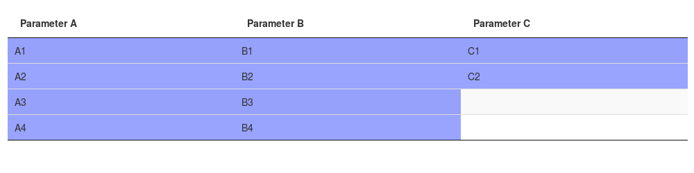

## An editable field

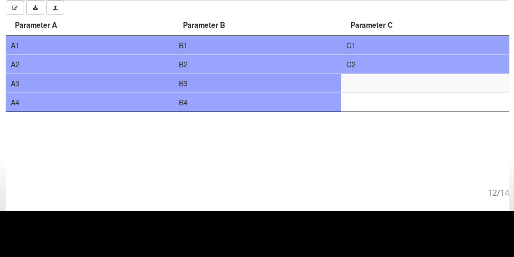

```r
morphr::installMorphField(input, output, id = "morphfield",
                          param_values = param_values,
                          configurations = configurations,
                          editable = TRUE)
```

## More complex example (made up)

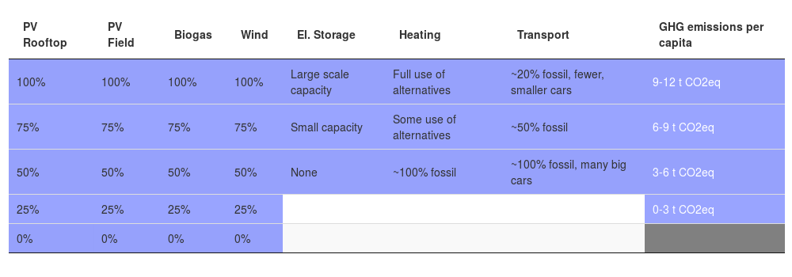

## Outlook

- `morphr` package still in early stage
  - Started in mid-February this year
  - Editing functionality added in June
  - Still missing: view and edit the CCM itself
- Hopefully, someone finds this helpful
  - As new visualization method
  - For structuring problems
- Code is on https://github.com/sgrubsmyon/morphr
- Slides repo: https://github.com/sgrubsmyon/morphr-talk-user2017
- Feel free to contribute, ask questions